# NREL R User Group: ggplot Introduction

Rebecca Hanes

October 3, 2017

# Preliminaries

Install and load the `ggplot2`, `ggExtra` and `reshape2` packages. Other packages may be required depending on what packages you already have installed.

# Data structure

Example of wide format data:

```r
names(midwest)
```

```
##  [1] "PID"                  "county"               "state"
##  [4] "area"                 "poptotal"             "popdensity"
##  [7] "popwhite"             "popblack"             "popamerindian"
## [10] "popasian"             "popother"             "percwhite"
## [13] "percblack"            "percamerindan"        "percasian"
## [16] "percother"            "popadults"            "perchsd"
## [19] "percollege"           "percprof"             "poppovertyknown"
## [22] "percpovertyknown"     "percbelowpoverty"     "percchildbelowpovert"
## [25] "percadultpoverty"     "percelderlypoverty"   "inmetro"
## [28] "category"
```

```r
head(midwest, n = 10)
```

```
## # A tibble: 10 x 28
##      PID    county state  area poptotal popdensity popwhite popblack
##    <int>     <chr> <chr> <dbl>    <int>      <dbl>    <int>    <int>
##  1   561     ADAMS    IL 0.052    66090  1270.9615    63917     1702
##  2   562 ALEXANDER    IL 0.014    10626   759.0000     7054     3496
##  3   563      BOND    IL 0.022    14991   681.4091    14477      429
##  4   564     BOONE    IL 0.017    30806  1812.1176    29344      127
##  5   565     BROWN    IL 0.018     5836   324.2222     5264      547
##  6   566    BUREAU    IL 0.050    35688   713.7600    35157       50
##  7   567   CALHOUN    IL 0.017     5322   313.0588     5298        1
##  8   568   CARROLL    IL 0.027    16805   622.4074    16519      111
##  9   569      CASS    IL 0.024    13437   559.8750    13384       16
## 10   570 CHAMPAIGN    IL 0.058   173025  2983.1897   146506    16559
## # ... with 20 more variables: popamerindian <int>, popasian <int>,
## #   popother <int>, percwhite <dbl>, percblack <dbl>, percamerindan <dbl>,
## #   percasian <dbl>, percother <dbl>, popadults <int>, perchsd <dbl>,
## #   percollege <dbl>, percprof <dbl>, poppovertyknown <int>,
## #   percpovertyknown <dbl>, percbelowpoverty <dbl>,
## #   percchildbelowpovert <dbl>, percadultpoverty <dbl>,
## #   percelderlypoverty <dbl>, inmetro <int>, category <chr>
```

Use the `melt` function in the `reshape2` package to convert wide format data to long format, and the `reshape` function to convert long format data to wide. Wide format data tends to be more human-readable than long format data, especially for smaller data sets.

Convert wide format data to long format and back again:

```r
# original data midwest is in wide format, convert to long format
midwest.long = melt(midwest,
                    id.vars = c('PID', 'county', 'state', 'area', 'category'))

# what are the new column names in long format?
names(midwest.long)
```

```
## [1] "PID"      "county"   "state"    "area"     "category" "variable"
## [7] "value"
```

```r
# what does the melted df look like?
head(midwest.long, n = 10)
```

```
##    PID    county state  area category variable  value
## 1  561     ADAMS    IL 0.052      AAR poptotal  66090
## 2  562 ALEXANDER    IL 0.014      LHR poptotal  10626
## 3  563      BOND    IL 0.022      AAR poptotal  14991
## 4  564     BOONE    IL 0.017      ALU poptotal  30806
## 5  565     BROWN    IL 0.018      AAR poptotal   5836
## 6  566    BUREAU    IL 0.050      AAR poptotal  35688
## 7  567   CALHOUN    IL 0.017      LAR poptotal   5322
## 8  568   CARROLL    IL 0.027      AAR poptotal  16805
## 9  569      CASS    IL 0.024      AAR poptotal  13437
## 10 570 CHAMPAIGN    IL 0.058      HAU poptotal 173025
```

```r
# what's in the variable column?
unique(midwest.long$variable)
```

```
##  [1] poptotal             popdensity           popwhite
##  [4] popblack             popamerindian        popasian
##  [7] popother             percwhite            percblack
## [10] percamerindan        percasian            percother
## [13] popadults            perchsd              percollege
## [16] percprof             poppovertyknown      percpovertyknown
## [19] percbelowpoverty     percchildbelowpovert percadultpoverty
## [22] percelderlypoverty   inmetro
## 23 Levels: poptotal popdensity popwhite popblack ... inmetro
```

```r
# reshape the long format data back to wide format
midwest.wide = reshape(midwest.long,
                       v.names = 'value',   # column that contains observations
                       timevar = 'variable', # column that contains variable names
                       idvar = c('PID', 'county', 'state', 'area', 'category'),  # columns that ID individual records
                       direction = 'wide')  # converts to wide format

# Now what are the column names?
names(midwest.wide)
```

```
##  [1] "PID"                        "county"
##  [3] "state"                      "area"
##  [5] "category"                   "value.poptotal"
##  [7] "value.popdensity"           "value.popwhite"
##  [9] "value.popblack"             "value.popamerindian"
## [11] "value.popasian"             "value.popother"
## [13] "value.percwhite"            "value.percblack"
## [15] "value.percamerindan"        "value.percasian"
## [17] "value.percother"            "value.popadults"
## [19] "value.perchsd"              "value.percollege"
## [21] "value.percprof"             "value.poppovertyknown"
## [23] "value.percpovertyknown"     "value.percbelowpoverty"
## [25] "value.percchildbelowpovert" "value.percadultpoverty"
## [27] "value.percelderlypoverty"   "value.inmetro"
```

```r
# What does the reshaped df look like?
head(midwest.wide, n = 10)
```

```
##    PID    county state  area category value.poptotal value.popdensity
## 1  561     ADAMS    IL 0.052      AAR          66090        1270.9615
## 2  562 ALEXANDER    IL 0.014      LHR          10626         759.0000
## 3  563      BOND    IL 0.022      AAR          14991         681.4091
## 4  564     BOONE    IL 0.017      ALU          30806        1812.1176
## 5  565     BROWN    IL 0.018      AAR           5836         324.2222
## 6  566    BUREAU    IL 0.050      AAR          35688         713.7600
## 7  567   CALHOUN    IL 0.017      LAR           5322         313.0588
## 8  568   CARROLL    IL 0.027      AAR          16805         622.4074
## 9  569      CASS    IL 0.024      AAR          13437         559.8750
## 10 570 CHAMPAIGN    IL 0.058      HAU         173025        2983.1897
##    value.popwhite value.popblack value.popamerindian value.popasian
## 1           63917           1702                  98            249
## 2            7054           3496                  19             48
## 3           14477            429                  35             16
```

[output cut: 73 more lines]

## Sidenote: Variable names

In long format, variable names should contain only one piece of information. For example, the variable name `percamerindian` has two pieces of information: that the observation is a percentage, and that the observation is of the Native American population. Some processing might be required to make plotting easier:

```r
# convert variable column from factor to character for easier processing
midwest.long$variable = as.character(midwest.long$variable)

# add column where "perc" or "pop" can be stored
midwest.long$var.type = NA

# fill $var.type with correct observation type
midwest.long$var.type[substr(midwest.long$variable, start = 1, stop = 3) == 'pop'] = 'pop'
midwest.long$var.type[substr(midwest.long$variable, start = 1, stop = 3) == 'per'] = 'pct'
midwest.long$var.type[!(substr(midwest.long$variable, start = 1, stop = 3) %in% c('per', 'pop'))] = 'other'

# add column to store the rest of the variable name
midwest.long$var.name = midwest.long$variable

# fill the new variable name column according to the $var.type value
midwest.long$var.name[midwest.long$var.type == 'pop'] = mapply(substr,
                                                               midwest.long$var.name[midwest.long$var.type == 'pop'],
                                                               start = 4,
                                                               stop = nchar(midwest.long$variable[midwest.long$var.type == 'pop']))
midwest.long$var.name[midwest.long$var.type == 'pct'] = mapply(substr,
                                                               midwest.long$var.name[midwest.long$var.type == 'pct'],
                                                               start = 5,
                                                               stop = nchar(midwest.long$variable[midwest.long$var.type == 'pct']))

# delete variable column which is now redundant
midwest.long$variable = NULL

# what does the processed data frame look like?
head(midwest.long, n = 10)
```

```
##    PID    county state  area category  value var.type var.name
## 1  561     ADAMS    IL 0.052      AAR  66090      pop    total
## 2  562 ALEXANDER    IL 0.014      LHR  10626      pop    total
## 3  563      BOND    IL 0.022      AAR  14991      pop    total
## 4  564     BOONE    IL 0.017      ALU  30806      pop    total
## 5  565     BROWN    IL 0.018      AAR   5836      pop    total
## 6  566    BUREAU    IL 0.050      AAR  35688      pop    total
## 7  567   CALHOUN    IL 0.017      LAR   5322      pop    total
## 8  568   CARROLL    IL 0.027      AAR  16805      pop    total
## 9  569      CASS    IL 0.024      AAR  13437      pop    total
## 10 570 CHAMPAIGN    IL 0.058      HAU 173025      pop    total
```

# Aesthetics and faceting

Depending on the plot type, available aesthetics include axis, line or border color (“color” or “colour”), area color (“fill”), point size, line thickness and line type. When aesthetics are controlled by categorical variables, they’re specified in the `aes()` command inside `ggplot()` or `geom_plottype()` commands.

```r
names(diamonds)
```

```
##  [1] "carat"   "cut"     "color"   "clarity" "depth"   "table"   "price"
##  [8] "x"       "y"       "z"
```

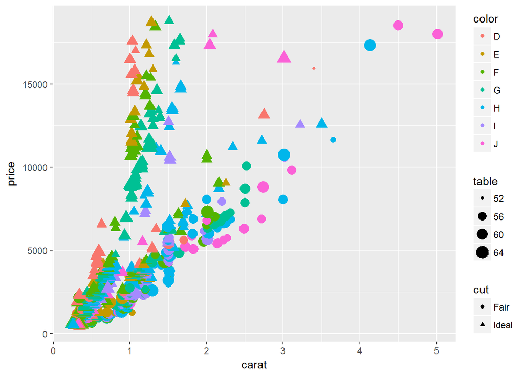

```r
diamonds.trim = subset(diamonds, cut %in% c('Fair', 'Ideal') & clarity %in% c('I1', 'IF'))

ggplot(diamonds.trim, aes(x = carat, y = price)) +
  geom_point(aes(colour = color, shape = cut, size = table))
```

Using too many aesthetics on the same plot can be confusing and make it difficult to interpret the plot. (Rule of thumb: Three separate legends is probably too complex; more than three separate legends is definitely too complex.) Adding facets along some categorical variables can increase clarity and free up aesthetics for use with other variables. Facets separate one plot into multiple sub-plots based on factor variable levels (categories).

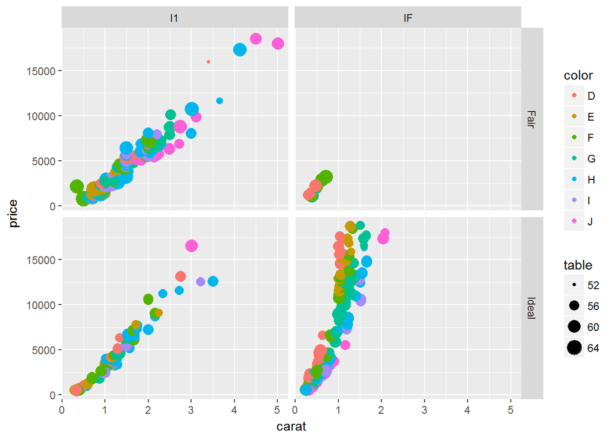

```r
ggplot(diamonds.trim, aes(x = carat, y = price)) +
  geom_point(aes(colour = color, size = table)) +
  facet_grid(cut ~ clarity)
```

Side note: Facet labels are one of the few plot labels that can’t be controlled with ggplot commands. To re-label facets, the data frame itself must be altered.

# Appearances

Appearances are set manually, outside the `aes()` command, unlike aesthetics which are controlled by categorical variables.

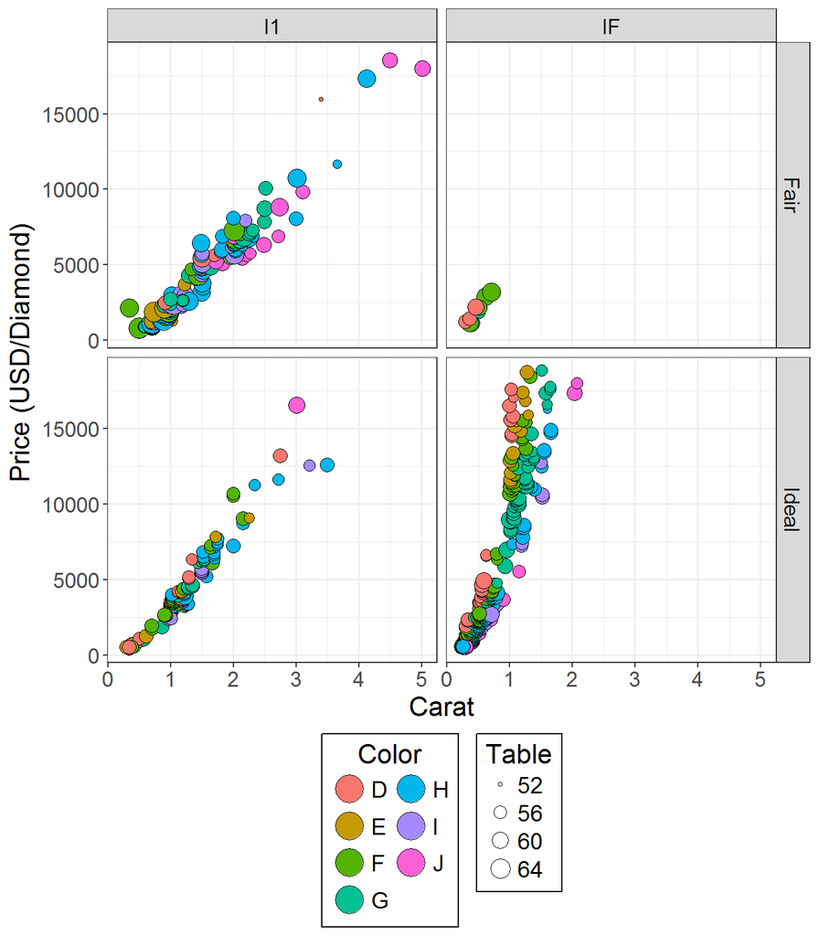

```r
ggplot(diamonds.trim, aes(x = carat, y = price)) +

  ## change the point shape to one which has a color and fill, to add a black outline to points
  # recall that "fill" sets the area color while "colo(u)r" sets the line or border color
  geom_point(aes(fill = color, size = table),
             shape = 21, colour = 'black') +
  facet_grid(cut ~ clarity) +


  ## change plot background color to white
  theme_bw() +

  ## set axis labels
  ylab('Price (USD/Diamond)') +
  xlab('Carat') +

  ## change point colors
  scale_color_brewer(palette = 'Set1') +

  ## tweak legend
  guides(fill = guide_legend('Color',  # change legend title
                             nrow = 4,  # arrange entries in 4 rows
                             override.aes = list(size = 8),  # increase the size of the points in legend
                             title.position = 'top',  # move title to left of legend
                             title.hjust = 0.5),  # vertically center title in legend
         size = guide_legend('Table',
                             nrow = 4,
                             title.position = 'top',
                             title.hjust = 0.5)) +

  ## do a variety of things
  theme(legend.position = 'bottom', # move legends to bottom of plot
        # draw a box around each legend
        legend.background = element_rect(colour = 'black',
                                         size = 0.5,
                                         linetype = 'solid'),
        ## increase font sizes
        # legend fonds
        legend.title = element_text(size = rel(1.5)),
        legend.text = element_text(size = rel(1.25)),
        # facet title fonts
        strip.text.y = element_text(size = rel(1.5)),
        strip.text.x = element_text(size = rel(1.5)),
        # axis tick mark labels
        axis.text.x = element_text(size = rel(1.5)),
        axis.text.y = element_text(size = rel(1.5)),
        # axis titles
        axis.title.x = element_text(size = rel(1.5)),
        axis.title.y = element_text(size = rel(1.5)))
```

`scale_color_brewer()` is a command from the `RColorBrewer` package that changes the default set of colors that ggplot uses. It’s an alternative to setting colours and fills (use `scale_fill_brewer`) individually, which can break easily if your data changes.

`guides()` controls legend appearance. Each entry sets the appearance for one aesthetic in the plot.

`theme()` controls fonts, more legend appearances (the settings inside `theme()` will apply to all legends in a plot), axis tick marks, and many other components.

Appearances can also be set outside of a ggplot command, to generate a set of plots with identical or similar appearances - this is useful for creating figures for an article or presentation.

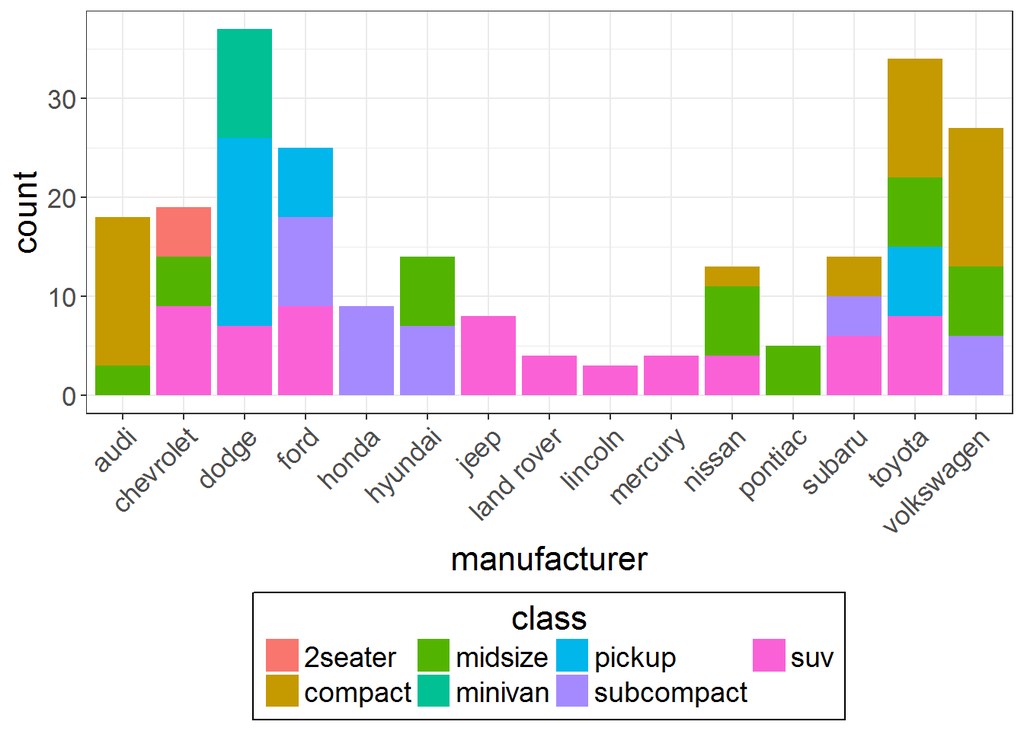

```r
# set theme for multiple plots
theme_set(theme_bw())
theme_update(legend.position = 'bottom',
              legend.background = element_rect(colour = 'black',
                                               size = 0.5,
                                               linetype = 'solid'),
              legend.title = element_text(size = rel(1.5)),
              legend.text = element_text(size = rel(1.25)),
              strip.text.y = element_text(size = rel(1.5)),
              strip.text.x = element_text(size = rel(1.5)),
              axis.text.x = element_text(angle = 45,
                                         hjust = 1,
                                         size = rel(1.5)),
              axis.text.y = element_text(size = rel(1.5)),
              axis.title.x = element_text(size = rel(1.5)),
              axis.title.y = element_text(size = rel(1.5)))

# create variable that holds legend parameters - title cannot be set this way with multiple legens per plot
legend.type = guide_legend(nrow = 2,
                           title.position = 'top',
                           title.hjust = 0.5)

## Stacked bar plot

ggplot(mpg, aes(x = manufacturer)) +
  geom_bar(aes(fill = class),
           stat = 'count', position = 'stack') +
  guides(fill = legend.type)
```

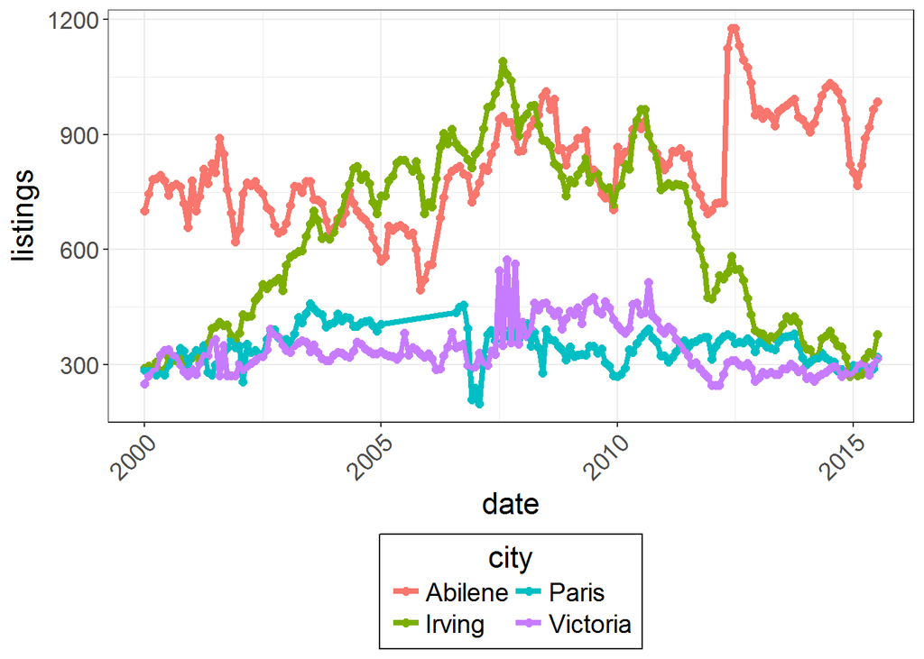

```r
txhousing.plot = subset(txhousing, city %in% c('Abilene', 'Irving', 'Paris', 'Victoria') &
                          !is.na(listings))

## Point and line plot

ggplot(txhousing.plot, aes(x = date, y = listings)) +
  geom_point(aes(colour = city), size = 2) +
  geom_line(aes(colour = city), size = 1.5) +
  guides(colour = legend.type)
```

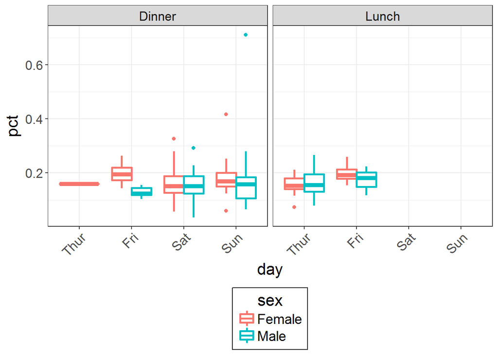

```r
tips.plot = tips
tips.plot$pct = tips.plot$tip / tips.plot$total_bill

tips.plot$day = factor(tips.plot$day,
                       levels = c('Thur', 'Fri', 'Sat', 'Sun'),
                       ordered = TRUE)

## Box plot

ggplot(tips.plot, aes(x = day, y = pct)) +
  geom_boxplot(aes(colour = sex), size = 1) +
  facet_grid(. ~ time) +
  guides(colour = legend.type)
```

# Basic examples

## Scatterplot plus linear regression line

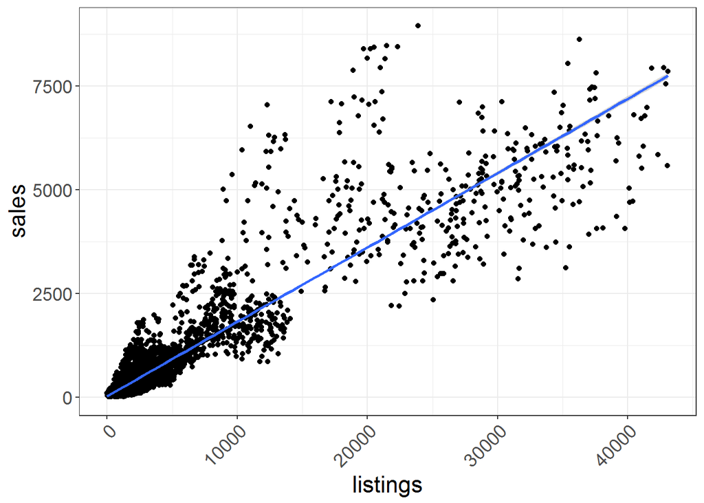

```r
txhousing.trim = subset(txhousing, !is.na(listings) & !is.na(sales))

ggplot(txhousing.trim,
       aes(x = listings, y = sales)) +
  geom_point() +
  geom_smooth(method = 'lm')  # add se = FALSE to geom_smooth() to remove confidence region
```

Get the regression equation, $R^2$ value and significance level:

```r
listings.sales.lm = lm(sales ~ listings,
                       data = txhousing.trim)

summary(listings.sales.lm)
```

```
##
## Call:
## lm(formula = sales ~ listings, data = txhousing.trim)
##
## Residuals:
##     Min      1Q  Median      3Q     Max
## -3225.0  -107.1   -42.2    20.9  4832.4
##
## Coefficients:
##              Estimate Std. Error t value Pr(>|t|)
## (Intercept) 2.266e+01  6.050e+00   3.746 0.000181 ***
## listings    1.793e-01  8.922e-04 200.913  < 2e-16 ***
## ---
## Signif. codes:  0 '***' 0.001 '**' 0.01 '*' 0.05 '.' 0.1 ' ' 1
##
## Residual standard error: 451.1 on 7174 degrees of freedom
## Multiple R-squared:  0.8491, Adjusted R-squared:  0.8491
## F-statistic: 4.037e+04 on 1 and 7174 DF,  p-value: < 2.2e-16
```

## Scatterplot plus marginal histogram

Install and load the `ggExtra` package to create this plot.

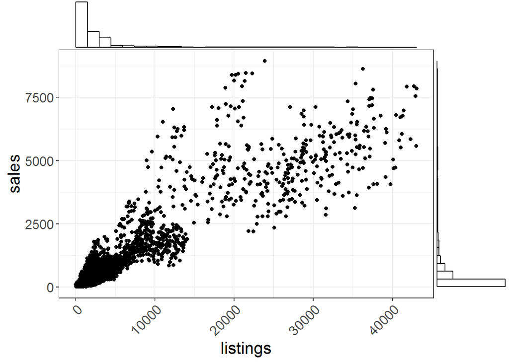

```r
tx.plot = ggplot(txhousing.trim,
                 aes(x = listings, y = sales)) +
          geom_point()

ggMarginal(tx.plot, type = 'histogram', fill = 'white')
```

## Combining data frames on one plot

Different data frames can be used for different calls of `geom_plottype` by specifying the data frame before `aes()`.

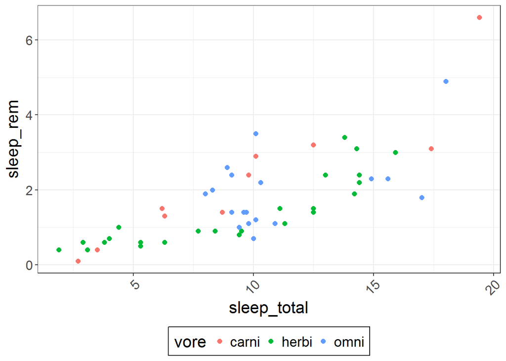

```r
msleep.carni = subset(msleep, vore == 'carni')
msleep.herbi = subset(msleep, vore == 'herbi')
msleep.omni = subset(msleep, vore == 'omni')

# create legend key to specify colors and labels
msleep.colours = c(carni = 'red',
                   herbi = 'darkgreen',
                   omni = 'blue')

# original plot has only carnivore data
ggplot(msleep.carni, aes(x = sleep_total, y = sleep_rem)) +
  geom_point(aes(colour = vore), size = 2) +

  # add in the herbivore data
  geom_point(data = msleep.herbi,
             aes(colour = vore), size = 2) +

  # add in the omnivore data
  geom_point(data = msleep.omni,
             aes(colour = vore), size = 2) +

  # add the legend
  scale_fill_manual(values = msleep.colours)
```

## Pie chart

Pie charts in ggplot are stacked bar charts in polar coordinates.

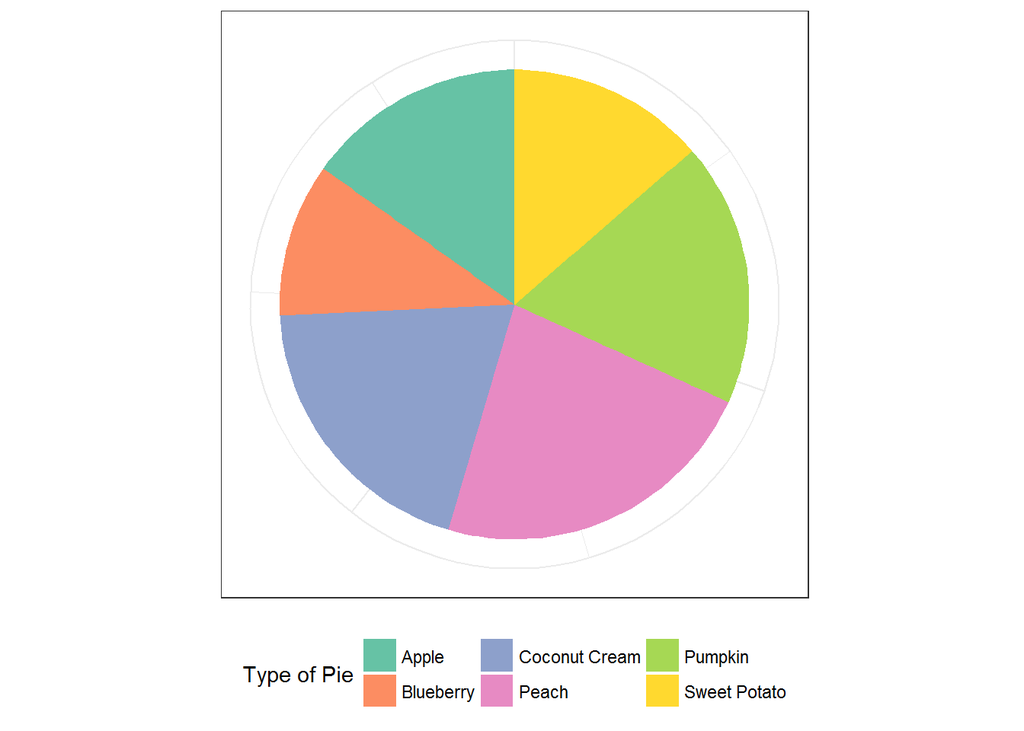

```r
pie.data = data.frame(type = c('Apple', 'Blueberry', 'Sweet Potato', 'Coconut Cream', 'Peach', 'Pumpkin'),
                      number = c(10, 7, 9, 13, 15, 12))

ggplot(pie.data, aes(x = factor(""),  # dummy variable to put all data in the same bar
                     y = number)) +

  geom_bar(aes(fill = type),
           width = 1,  # pie chart is filled in at the center
           stat = 'identity',  # plotting data, not counts
           position = 'stack') +   # stacked chart

  coord_polar(theta = 'y') +  # convert bar chart to pie chart

  scale_fill_brewer(palette = 'Set2') +  # change color set

  guides(fill = guide_legend('Type of Pie',  # change legend title
                             nrow = 2)) +  # put entries into 2 rows

  theme_bw() +

  theme(legend.position = 'bottom',
        # blank out the axis title, labels and tick marks for a clean look
        axis.title.x = element_blank(),
        axis.text.x = element_blank(),
        axis.title.y = element_blank(),
        axis.text.y = element_blank(),
        axis.ticks.y = element_blank())
```

## Adding error bars

To include error bars on a plot (point, line, bar or other), the upper and lower error limits must be stored in two separate columns as absolute values, not +/- percent or value.

```r
head(err.data)
```

```
##         day temp temp.min temp.max
## 1 Last Week 82.1       80       84
## 2 Yesterday 50.4       61       45
## 3     Today 42.9       48       32
## 4  Tomorrow 39.9       43       29
## 5 Next Week 75.0       82       70
```

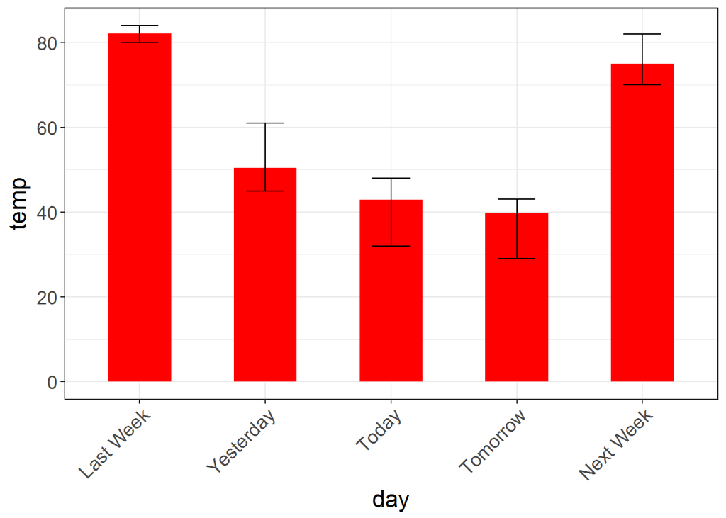

```r
ggplot(err.data, aes(x = day, y = temp)) +

  geom_bar(width = 0.5, fill = 'red',
           stat = 'identity') +

  geom_errorbar(aes(x = day,  # same x-aesthetic as the bar chart
                    ymin = temp.min,  # define lower and upper limits of error bars
                    ymax = temp.max),
                color = 'black',  # set color to contrast with bar color
                width = 0.3)  # decrease the width of the horizontal part of the error bars
```

## Labels on graphs

Use `geom_label()` or `geom_text()` to add text to graphs. `geom_label` puts text in a rectangle with the same line color as the font color, while `geom_text()` just adds text.

Simple labels with location, text, color, size and other aesthetics specified manually:

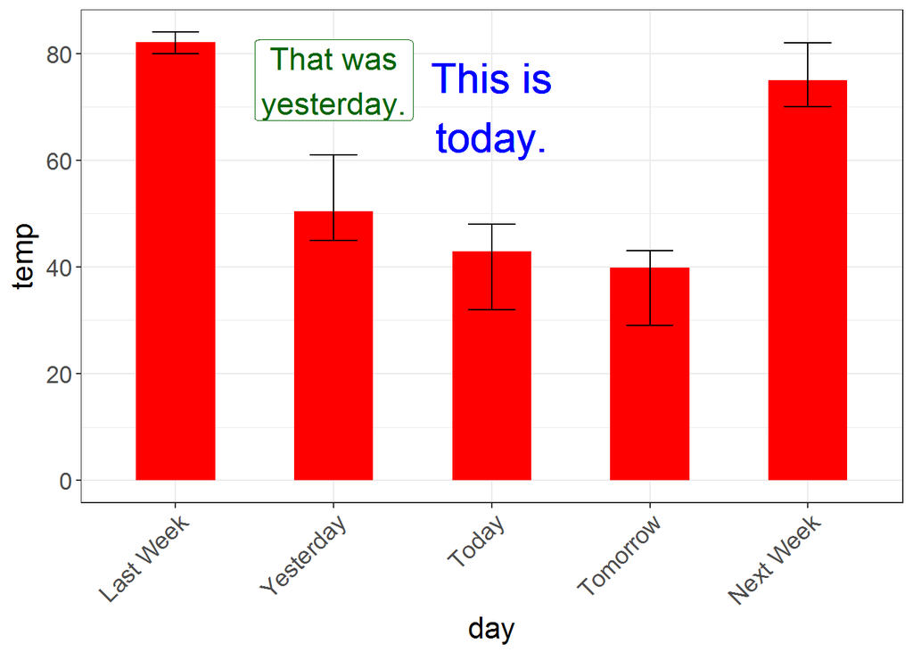

```r
ggplot(err.data, aes(x = day, y = temp)) +
  geom_bar(width = 0.5, fill = 'red',
           stat = 'identity') +
  geom_errorbar(aes(x = day, ymin = temp.min, ymax = temp.max),
                color = 'black', width = 0.3) +

  geom_text(aes(x = 'Today',  # label the 'Today' bar
                y = 70,  # set the y-coordinate
                label = 'This is\ntoday.'),  # label text
            color = 'blue', size = 8) +  # label color and size are not determiend by data, so are outside aes()

  geom_label(aes(x = 'Yesterday',  # label the 'Yesterday' bar
                 y = 75,  # set the y-coordinate
                 label = 'That was\nyesterday.'), # label text
             color = 'darkgreen', size = 6)  # set label color, size manually
```

This syntax works for single-facet plots or for applying identical labels to all facets of a plot. To apply many labels or vary labels by facets, the label text and location should be stored in the data frame as additional columns.

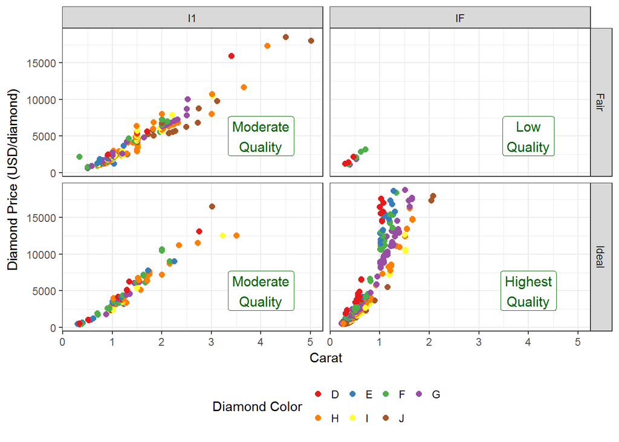

```r
# create extra column for label
# label position will be the same in all facets - no need for position columns
diamonds.trim$label.text = NA

# assign label text based on values of cut and clarity
# the '\n' character inserts a new line in the label
diamonds.trim$label.text[diamonds.trim$cut == 'Fair' & diamonds.trim$clarity == 'IF'] = 'Low\nQuality'
diamonds.trim$label.text[diamonds.trim$cut == 'Fair' & diamonds.trim$clarity == 'I1'] = 'Moderate\nQuality'
diamonds.trim$label.text[diamonds.trim$cut == 'Ideal' & diamonds.trim$clarity == 'I1'] = 'Moderate\nQuality'
diamonds.trim$label.text[diamonds.trim$cut == 'Ideal' & diamonds.trim$clarity == 'IF'] = 'Highest\nQuality'

ggplot(diamonds.trim,
       aes(x = carat, y = price)) +
  geom_point(aes(colour = color),
             size = 2) +

  ## Note that label position is not inside the aes() command because it is set manually
  geom_label(aes(label = label.text),
             x = 4, y = 5000, size = 4, color = 'darkgreen') +

  facet_grid(cut ~ clarity) +
  ylab('Diamond Price (USD/diamond)') +
  xlab('Carat') +
  theme_bw() +
  scale_color_brewer(palette = 'Set1') +
  guides(colour = guide_legend('Diamond Color', nrow = 2, byrow = TRUE)) +
  theme(legend.position = 'bottom')
```

# Automatically saving plots

`png(file = 'filename.png')` and `svg(file = 'filename.svg')` commands save plots with optional specific dimensions and, for PNG images, resolution. The image-creation command goes immediately before the plot creation (ie line before `ggplot()` is called), and the command `dev.off()` goes immediately after plot creation. When these commands are used, the plot does not display.

Plots can be saved manually via point-and-click, but using the commands makes it much easier to update figures without having to re-specify image size each time. The command also allows resolution to be specified if saving PNG images for Word documents and PowerPoint presentations, which is essential if the figure size will be altered at all in the document.

```r
# plot to save as PNG
png('diamonds-scatter.png', width = 3000, height = 3000, res = 500)
ggplot(diamonds.trim,
       aes(x = carat, y = price)) +
  geom_point(aes(colour = color),
             size = 2) +

  ## Note that label position is not inside the aes() command because it is set manually
  geom_label(aes(label = label.text),
             x = 4, y = 5000, size = 4, color = 'darkgreen') +

  facet_grid(cut ~ clarity) +
  ylab('Diamond Price (USD/diamond)') +
  xlab('Carat') +
  theme_bw() +
  scale_color_brewer(palette = 'Set1') +
  guides(colour = guide_legend('Diamond Color', nrow = 2, byrow = TRUE)) +
  theme(legend.position = 'bottom')
dev.off()
```

SVG files will be larger in size than PNG files, particularly for plots showing a lot of data. The plot below saves at about 20 MB.

```r
# plot to save as SVG - cannot specify resolution
svg('diamonds-scatter.svg', width = 5, height = 5)
ggplot(diamonds.trim,
       aes(x = carat, y = price)) +
  geom_point(aes(colour = color),
             size = 2) +

  ## Note that label position is not inside the aes() command because it is set manually
  geom_label(aes(label = label.text),
             x = 4, y = 5000, size = 4, color = 'darkgreen') +

  facet_grid(cut ~ clarity) +
  ylab('Diamond Price (USD/diamond)') +
  xlab('Carat') +
  theme_bw() +
  scale_color_brewer(palette = 'Set1') +
  guides(colour = guide_legend('Diamond Color', nrow = 2, byrow = TRUE)) +
  theme(legend.position = 'bottom')
dev.off()
```

# A ggplot hack: breaking the y-axis

This hack involves the creative use of facets and some optional image processing in Inkscape or another svg graphics editor. Data should be in the long format, so categorical variables can be added and used for faceting.

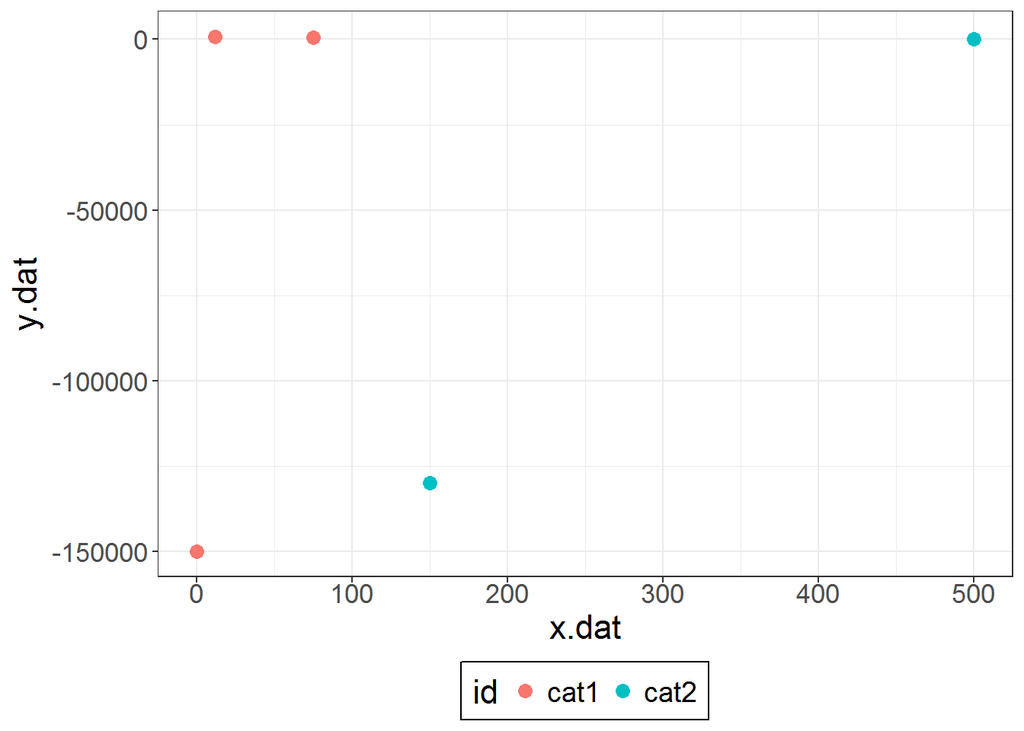

```r
theme_replace(axis.text.x = element_text(size = rel(1.5)))

difficult.data = data.frame(x.dat = c(0, 12, 500, 150, 75),
                            y.dat = c(-150000, 800, 0.1, -130000, 500),
                            id = c('cat1', 'cat1', 'cat2', 'cat2', 'cat1'))

ggplot(difficult.data, aes(x = x.dat, y = y.dat)) +
  geom_point(aes(colour = id),
             size = 3)
```

Add a variable dividing points into two groups, one appearing above the axis break and one below the axis break. Facet on this variable and set the y-axis scales to free, so the scale on both facets is determined by the data in that facet.

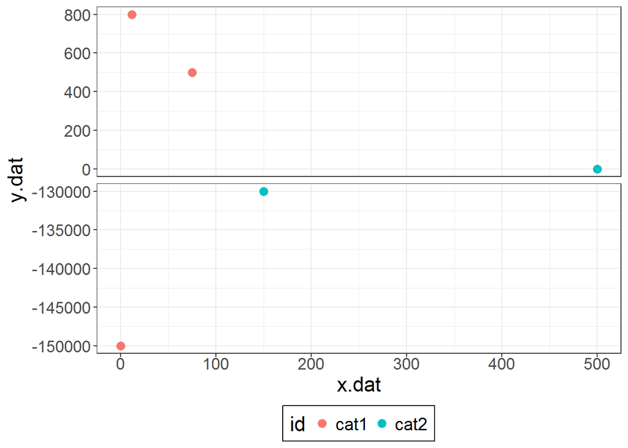

```r
difficult.data$y.axis[difficult.data$y.dat < 0] = 'below'
difficult.data$y.axis[difficult.data$y.dat >= 0] = 'above'

ggplot(difficult.data, aes(x = x.dat, y = y.dat)) +
  geom_point(aes(colour = id),
             size = 3) +
  facet_grid(y.axis ~ .,
             scales = 'free_y') +
  theme(strip.text.y = element_blank())
```

Include y = 0 on both facets by adding a dummy point that can be removed in postprocessing:

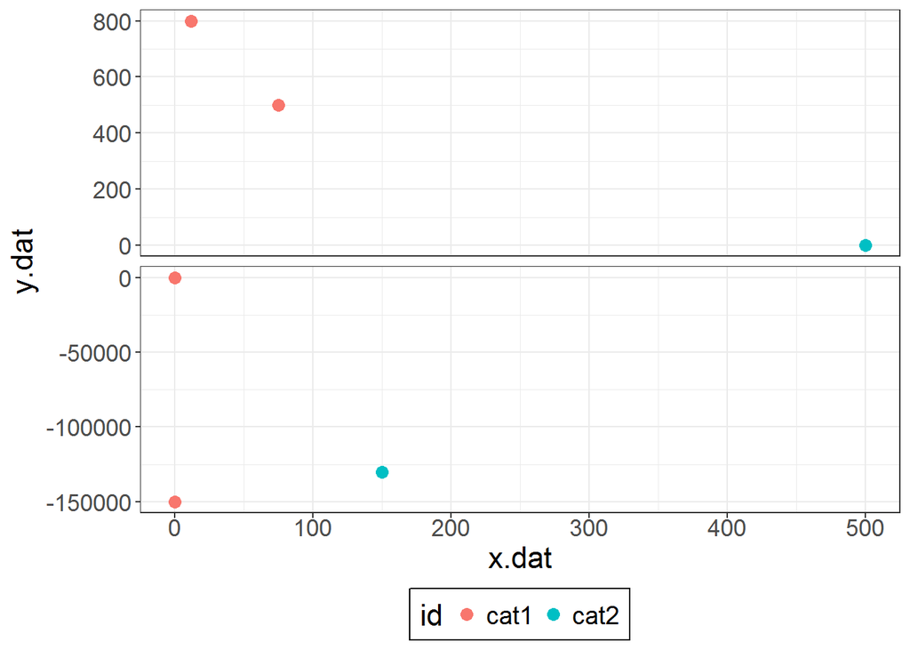

```r
difficult.data = rbind(difficult.data,
                       data.frame(x.dat = 0,
                                  y.dat = 0,
                                  id = 'cat1',
                                  y.axis = 'below'))

ggplot(difficult.data, aes(x = x.dat, y = y.dat)) +
  geom_point(aes(colour = id),
             size = 3) +
  facet_grid(y.axis ~ .,
             scales = 'free_y') +
  theme(strip.text.y = element_blank())
```

Clean up with image post-processing or leave as is.

# Further resources

- Use `?functionname` to access built-in R help
- Google “ggplot + [action]” to find solutions from R’s online user base

## Helpful websites

1. [Getting started in ggplot](http://r4stats.com/examples/graphics-ggplot2/)
2. [R cookbook](http://www.cookbook-r.com/Graphs/)
3. [ggplot cheatsheet](http://zevross.com/blog/2014/08/04/beautiful-plotting-in-r-a-ggplot2-cheatsheet-3/)
4. [Fifty example plots with code](http://r-statistics.co/Top50-Ggplot2-Visualizations-MasterList-R-Code.html)
5. [More example plots](http://www.r-graph-gallery.com/portfolio/ggplot2-package/)
6. [Map and shapefile example #1](https://www.r-bloggers.com/plotting-choropleths-from-shapefiles-in-r-with-ggmap-toronto-neighbourhoods-by-population/)
7. [Map and shapefile example #2](http://www.markhneedham.com/blog/2014/11/17/r-ggmap-overlay-shapefile-with-filled-polygon-of-regions/)